# Developing Heart Failure Risk Score for Diabetic Patients by Deep Learning from Electronic Health Records

Our goal is to develop and validate deep learning models for predicting incident heart failure (HF) events in patients with Diabetes mellitus (DM) using electronic health records (EHRs) data. Patients with diabetes are at increased risk for developing HF, leading to a tremendous personal health burden and substantial healthcare cost. Identifying patients with diabetes at highest risk for HF will enable delivery of personalized preventive treatment strategies to those individuals at greatest need.

## Cohort Extraction Description

We originally identified 3,668,780 patients with at least one encounter with an ICD code (ICD 9 / ICD-10-CA / ICD-10-CM) for diabetes or an associated diabetes complication out of which:

- 14,407 patients with Diabetes Insipidus [diagnosis_code in ( '253.5','E23.2','588.1','N25.1')), who we identified to exclude from our cohort in case those patients were incorrectly documented for DM within the EHR.]
- 80,237 patients with gestiginal(preganacy) or history of gestiginal DM [ICD-9 '648%', ICD-10 like 'O24%' or in ('Z86.32', 'V12.21')]
- 30,182 Neonatal DM patients or infant of Diabetic Mother [ICD-9 '775%' /ICD-10 'P70%']
- 49,848 Patients with Secondary DM [ICD-9 like '249%' or ICD-10 like 'E08%' or 'E09%' ]
- 304,949 with Type I DM [ICD-10 like E10%' or ICD-9 in ('250.01','250.03','250.13','250.81','250.61','250.41','250.63', '250.51','250.83','250.11','250.43','250.93','250.53','250.91','250.71','250.21','250.73','250.23','250.33','250.31')]

We decided to exclude the above patients from our cohort as we will focus on patients with type II DM and need to avoid any chance of wrong coding considering that most of the EHR data are based on user manual enteries and there is a high associated chance of data entry mistakes. For the same reason we decided to include patients that have more than encounter with a diabetes diagnosis code, hence we excluded 1,650,736 patients who only showed 1 encounter with a diabetes diagnosis.

For Cases, we identified patient with incidences of heart failure [using ICD-9_codes like '428%' in ('404.03','404.13','402.11','404.11','402.01','404.01','402.91','398.91','404.93','404.91') or ICD-10 codes like 'I50%' or in ('I11.0','I09.81','I13.2','I97.13','I97.131','I13.0','I97.130')]

we identified 587,906 patients from the original cohort reported HF along with DM, among which:

```
- 90,856 patients reported HF before DM.
- 226,589 patients reported HF on the same day as DM.
- 268,080 patients reported HF after DM encounter discharge
```

We applied all exclusion criteria described for DM on those 268,080 patients, and for a more conservetive definition of our cases we selected patients who reported HF at least 30 days after their first encounter with a type II DM code. we also excluded patients with only one HF encounter for quality.

Further data cleaning, include exclusion of patients with incorrect or incomplete data, for example patients who were recorded as expired in between their first encounter and our event (first HF encounter for cases or last encounter for controls), as well as patients who are younger than 18 years old at their first diabetes diagnosis.

Cerner HealthFacts v.2017 includes 17,629 ICD9 codes, 94,044 ICD10-CM and 16,044 ICD10-CA, as well as 3,385 unique medication generic name, Our cohort uses around 69,056 code out of which around 65,000 are either ICD 9 or 10 codes and the rest are medication generic names. We additionlly tested using UMLS Cui for diagnosis for better generalizability, the total count of codes used decreased to around 50,000 codes when using UMLS.

Further improvement for the cohort based on previous reviewer comments include:

1. For DMII patients, besides the original criteria, we verified that the patients A1C reading is >=6.5 or they are taking one of the antidiabetic agents namely: metformin chlorpropamide glimepiride glyburide glipizide tolbutamide tolazamide pioglitazone rosiglitazone sitagliptin saxagliptin alogliptin linagliptin repaglinide nateglinide miglitol acarbose insulin
2. For Heart Failure, besides the original criteria, we verified that the patients are either prescribed a diuretic agent, have high BNP or have been a subject for any dialysis or artificifical heart asociated procedure or similar.

Hence the final cohort analysed below include 39,727 cases and 632,920 controls

[figure not shown]

#### Required Tools and Packages

We mostly use scikit-learn for baseline machine learning, plotly and matpoltlib for visualization within ipython notebooks, but we also use Tableau aside of it.

For baseline survival analysis we used the lifelines package, and hence we used the compatabile matplotlib (2.2) and pandas (1.8) versions.

For deep learning we rely on Pytorch framework (v1), GPU enabling accelerate the computational performance,and for the full set model trainings we might need to utilize the Pytorch DataParallel functionality for parallel GPU computing.

```python
### Tools and Packages
##Basics
import pandas as pd
import numpy as np
import sys, random
import math
try:
    import cPickle as pickle
except:
    import pickle
import string
import re
import os
import time
from tqdm import tqdm


## ML and Stats
from sklearn import datasets, linear_model
from sklearn.linear_model import LinearRegression
import sklearn.metrics as m
import sklearn.linear_model  as lm
import lifelines as ll #for survival analysis
from lifelines.fitters.kaplan_meier_fitter import KaplanMeierFitter
from sklearn.metrics import roc_auc_score
from sklearn.ensemble import RandomForestClassifier
from sklearn.preprocessing import MultiLabelBinarizer
from sklearn.tree import export_graphviz
import statsmodels.api as sm
#import statsmodels.formula.api as sm
import patsy
from scipy import stats

## Visualization
import matplotlib
import matplotlib.pyplot as plt
from matplotlib.pyplot import cm
%matplotlib inline
from plotly.offline import download_plotlyjs, init_notebook_mode, plot, iplot
init_notebook_mode()
import chart_studio.plotly as py
import plotly.tools as tls
import plotly.graph_objs as go
from plotly.graph_objs import *
from IPython.display import HTML

## DL Framework
import torch
import torch.nn as nn
from torch.nn import Parameter
import torch.nn.functional as F
from torch.autograd import Variable
from torch import optim



###GPU enabling and device allocation
use_cuda = torch.cuda.is_available()
torch.cuda.set_device(1)
```

## Cohort Description

```python
Filename="../raw_data/lr_DHF_tmp5_demo_socioe.txt"
cohort_demo_socio_df= pd.read_csv(Filename,sep='\t')
```

```python
cohort_demo_socio_df.sample(10)
```

|  | patient_sk | ind_adm_dt | diab_adm_dt | gender | race | race_cat | marital_status | marital_cat | yob | age_ondiab | ... | census_division | vis_cnts | label | religion | language | insurance | smoking_events | smoking | alcohol_events | alcohol |
| --- | --- | --- | --- | --- | --- | --- | --- | --- | --- | --- | --- | --- | --- | --- | --- | --- | --- | --- | --- | --- | --- |
| 567958 | 180832029 | 2014-01-27 | 2012-12-25 | Male | Caucasian | White | Married | Partner | 1952.0 | 60.0 | ... | 9 | 2 | ctrl | Unknown | Unknown | Other Commercial Payer | 3 | Y | 2 | Y |
| 446426 | 124045565 | 2006-03-18 | 2005-04-29 | Female | Caucasian | White | Widowed | Separated | 1922.0 | 83.0 | ... | 1 | 22 | ctrl | Unknown | Unknown | Blue Cross/Blue Shield | 0 | N | 0 | N |
| 164301 | 196373244 | 2016-03-23 | 2013-01-31 | Female | Caucasian | White | Widowed | Separated | 1941.0 | 72.0 | ... | 2 | 41 | ctrl | Christian | English | Medicare | 0 | N | 0 | N |
| 174592 | 147121949 | 2017-09-18 | 2014-10-20 | Male | Caucasian | White | Married | Partner | 1965.0 | 49.0 | ... | 6 | 15 | ctrl | Christian | English | Other Commercial Payer | 0 | N | 0 | N |
| 267065 | 122612379 | 2015-07-10 | 2012-10-30 | Male | Caucasian | White | Married | Partner | 1935.0 | 77.0 | ... | 2 | 4 | ctrl | Unknown | Not Mapped | Medicare | 3 | Y | 3 | Y |
| 609934 | 323766089 | 2017-09-26 | 2012-06-20 | Male | Caucasian | White | Married | Partner | 1951.0 | 61.0 | ... | 9 | 44 | ctrl | Unknown | English | Medicare | 0 | N | 0 | N |
| 586601 | 129922737 | 2017-12-11 | 2017-04-21 | Male | Unknown | UnKnown | Single | Single | 1971.0 | 46.0 | ... | 2 | 6 | ctrl | Unknown | English | Medicare | 0 | N | 0 | N |
| 115615 | 126986663 | 2013-05-07 | 2010-12-21 | Female | Caucasian | White | Married | Partner | 1953.0 | 57.0 | ... | 3 | 34 | ctrl | Unknown | Unknown | Blue Cross/Blue Shield | 2 | Y | 4 | Y |
| 330243 | 108802518 | 2015-06-25 | 2015-06-22 | Female | Caucasian | White | Widowed | Separated | 1925.0 | 90.0 | ... | 8 | 1 | ctrl | Christian | English | Other Commercial Payer | 0 | N | 0 | N |
| 663684 | 150840745 | 2017-06-09 | 2009-02-18 | Female | Caucasian | White | Married | Partner | 1947.0 | 62.0 | ... | 5 | 11 | ctrl | Unknown | Not Mapped | Blue Cross/Blue Shield | 0 | N | 0 | N |

10 rows × 23 columns

```python
#### Basic Summary Statistics
### Primary Exploration
cohort_demo_df=cohort_demo_socio_df[['patient_sk','label','gender','race_cat','marital_cat','insurance','age_ondiab','smoking','alcohol','age_onevent','census_region','vis_cnts']].drop_duplicates()
cohort_demo_df=cohort_demo_df[cohort_demo_df['age_ondiab']>=18]
SumC=cohort_demo_df['label'].value_counts()
summNcg=cohort_demo_df['gender'].groupby(cohort_demo_df['label']).value_counts(normalize=True).transpose()
summNcr=cohort_demo_df['race_cat'].groupby(cohort_demo_df['label']).value_counts(normalize=True)
summNcm=cohort_demo_df['marital_cat'].groupby(cohort_demo_df['label']).value_counts(normalize=True)
summNci=cohort_demo_df['insurance'].groupby(cohort_demo_df['label']).value_counts(normalize=True)
summN=cohort_demo_df[['race_cat' ,'gender','insurance']].groupby(cohort_demo_df['label']).describe()#.transpose()
summNs=cohort_demo_df[['smoking' ,'alcohol','marital_cat']].groupby(cohort_demo_df['label']).describe()#.transpose()
summNr=cohort_demo_df[['race_cat' ,'gender','insurance']].groupby(cohort_demo_df['census_region']).describe()#.transpose()
summNsr=cohort_demo_df[['smoking' ,'alcohol','marital_cat']].groupby(cohort_demo_df['census_region']).describe()#.transpose()

summC=cohort_demo_df[['age_ondiab']].groupby(cohort_demo_df['label']).describe().transpose()
summCe=cohort_demo_df[['age_onevent']].groupby(cohort_demo_df['label']).describe().transpose()
summCv=cohort_demo_df[['vis_cnts']].groupby(cohort_demo_df['label']).describe().transpose()
summCvr=cohort_demo_df[['vis_cnts']].groupby(cohort_demo_df['census_region']).describe().transpose()

print('\x1b[1;30m'+'Cohort :'+'\x1b[0m')#, SumC)
display(summN)
display(summNs)
display(summNr)
display(summNsr)
print('\x1b[1;30m'+'Different demographics distribution: \n'+'\x1b[0m')
display(summNcg)
display(summNcr)
display(summNcm)
display(summNci)
display(summC,summCe,summCv,summCvr)
```

```
Cohort :
```

| label | race_cat count | race_cat unique | race_cat top | race_cat freq | gender count | gender unique | gender top | gender freq | insurance count | insurance unique | insurance top | insurance freq |
| --- | --- | --- | --- | --- | --- | --- | --- | --- | --- | --- | --- | --- |
| case | 39733 | 5 | White | 31599 | 39733 | 3 | Female | 20245 | 37250 | 21 | Medicare | 23074 |
| ctrl | 633183 | 5 | White | 472624 | 633183 | 3 | Female | 331549 | 610604 | 24 | Medicare | 243081 |

| label | smoking count | smoking unique | smoking top | smoking freq | alcohol count | alcohol unique | alcohol top | alcohol freq | marital_cat count | marital_cat unique | marital_cat top | marital_cat freq |
| --- | --- | --- | --- | --- | --- | --- | --- | --- | --- | --- | --- | --- |
| case | 39733 | 2 | N | 28457 | 39733 | 2 | N | 29359 | 39733 | 4 | Partner | 17451 |
| ctrl | 633183 | 2 | N | 460500 | 633183 | 2 | N | 468178 | 633183 | 4 | Partner | 318322 |

| census_region | race_cat count | race_cat unique | race_cat top | race_cat freq | gender count | gender unique | gender top | gender freq | insurance count | insurance unique | insurance top | insurance freq |
| --- | --- | --- | --- | --- | --- | --- | --- | --- | --- | --- | --- | --- |
| Midwest | 145046 | 5 | White | 104533 | 145046 | 3 | Female | 75519 | 140837 | 19 | Medicare | 53058 |
| Northeast | 173824 | 5 | White | 144342 | 173824 | 3 | Female | 87587 | 167116 | 20 | Medicare | 71240 |
| South | 220636 | 5 | White | 158212 | 220636 | 3 | Female | 118640 | 212506 | 18 | Medicare | 94000 |
| West | 133410 | 5 | White | 97136 | 133410 | 3 | Female | 70048 | 127395 | 20 | Medicare | 47857 |

| census_region | smoking count | smoking unique | smoking top | smoking freq | alcohol count | alcohol unique | alcohol top | alcohol freq | marital_cat count | marital_cat unique | marital_cat top | marital_cat freq |
| --- | --- | --- | --- | --- | --- | --- | --- | --- | --- | --- | --- | --- |
| Midwest | 145046 | 2 | N | 93772 | 145046 | 2 | N | 102193 | 145046 | 4 | Partner | 70174 |
| Northeast | 173824 | 2 | N | 129303 | 173824 | 2 | N | 141462 | 173824 | 4 | Partner | 82155 |
| South | 220636 | 2 | N | 151392 | 220636 | 2 | N | 136528 | 220636 | 4 | Partner | 114978 |
| West | 133410 | 2 | N | 114490 | 133410 | 2 | N | 117354 | 133410 | 4 | Partner | 68466 |

```
Different demographics distribution:
```

```
label  gender
case   Female     0.509526
       Male       0.490348
       Unknown    0.000126
ctrl   Female     0.523623
       Male       0.476158
       Unknown    0.000220
Name: gender, dtype: float64
```

```
label  race_cat
case   White               0.795284
       African American    0.164674
       UnKnown             0.022953
       Asian/Pacific       0.016284
       MultiRace           0.000805
ctrl   White               0.746426
       African American    0.157766
       UnKnown             0.066095
       Asian/Pacific       0.028493
       MultiRace           0.001221
Name: race_cat, dtype: float64
```

```
label  marital_cat
case   Partner        0.439207
       Separated      0.342889
       Single         0.153021
       Unknown        0.064883
ctrl   Partner        0.502733
       Single         0.213693
       Separated      0.210541
       Unknown        0.073033
Name: marital_cat, dtype: float64
```

```
label  insurance
case   Medicare                                0.619436
       Blue Cross/Blue Shield                  0.079141
       HMO/Managed Care (undesignated)         0.073557
       Medicaid                                0.049638
       Other Commercial Payer                  0.046121
       Medicare Managed Care (undesignated)    0.038282
       Self-Pay                                0.019034
       Other Non-Govt                          0.012510
       PPO (undesignated)                      0.010872
       Other Government                        0.010255
       Unknown / Missing / Invalid             0.010148
       CHAMPUS (Military dependents)           0.009852
       Not Mapped                              0.009315
       Medicaid Managed Care (undesignated)    0.009128
       Free, Research                          0.001074
       MIA                                     0.000832
       Worker's Compensation                   0.000483
       Self-Insured                            0.000134
       Medicare Psychiatric                    0.000107
       Other                                   0.000054
       Title V                                 0.000027
ctrl   Medicare                                0.398099
       Blue Cross/Blue Shield                  0.162236
       HMO/Managed Care (undesignated)         0.099990
       Medicaid                                0.093814
       Other Commercial Payer                  0.071572
       Self-Pay                                0.033917
       Medicare Managed Care (undesignated)    0.027712
       Other Non-Govt                          0.022098
       Medicaid Managed Care (undesignated)    0.019507
       PPO (undesignated)                      0.019274
       Not Mapped                              0.017538
       Unknown / Missing / Invalid             0.010568
       CHAMPUS (Military dependents)           0.009283
       Other Government                        0.008996
       Free, Research                          0.002077
       Worker's Compensation                   0.001181
       MIA                                     0.001107
       Self-Insured                            0.000409
       Other                                   0.000300
       Title V                                 0.000159
       Medicare Psychiatric                    0.000087
       Commercial/Indemnity Insurance          0.000043
       Managed Care                            0.000025
       Medicare Rehab.                         0.000010
Name: insurance, dtype: float64
```

|  | label | case | ctrl |
| --- | --- | --- | --- |
| age_ondiab | count | 39733.000000 | 633183.000000 |
|  | mean | 69.367730 | 60.379423 |
|  | std | 12.124314 | 13.572371 |
|  | min | 18.000000 | 18.000000 |
|  | 25% | 61.000000 | 51.000000 |
|  | 50% | 71.000000 | 61.000000 |
|  | 75% | 79.000000 | 70.000000 |
|  | max | 94.000000 | 98.000000 |

|  | label | case | ctrl |
| --- | --- | --- | --- |
| age_onevent | count | 39733.000000 | 633183.000000 |
|  | mean | 71.560818 | 63.642715 |
|  | std | 12.085554 | 13.680358 |
|  | min | 19.000000 | 18.000000 |
|  | 25% | 64.000000 | 55.000000 |
|  | 50% | 73.000000 | 64.000000 |
|  | 75% | 81.000000 | 73.000000 |
|  | max | 97.000000 | 101.000000 |

|  | label | case | ctrl |
| --- | --- | --- | --- |
| vis_cnts | count | 39733.000000 | 633183.000000 |
|  | mean | 23.000956 | 28.826420 |
|  | std | 30.700657 | 34.128127 |
|  | min | 1.000000 | 1.000000 |
|  | 25% | 5.000000 | 8.000000 |
|  | 50% | 13.000000 | 18.000000 |
|  | 75% | 28.000000 | 37.000000 |
|  | max | 564.000000 | 1274.000000 |

|  | census_region | Midwest | Northeast | South | West |
| --- | --- | --- | --- | --- | --- |
| vis_cnts | count | 145046.000000 | 173824.000000 | 220636.000000 | 133410.000000 |
|  | mean | 37.363223 | 31.461616 | 19.435215 | 29.907938 |
|  | std | 41.702256 | 34.493242 | 22.405073 | 36.226192 |
|  | min | 1.000000 | 1.000000 | 1.000000 | 1.000000 |
|  | 25% | 10.000000 | 9.000000 | 6.000000 | 8.000000 |
|  | 50% | 24.000000 | 21.000000 | 13.000000 | 19.000000 |
|  | 75% | 50.000000 | 41.000000 | 25.000000 | 38.000000 |
|  | max | 798.000000 | 819.000000 | 784.000000 | 1274.000000 |

N.B. The slight difference in counts above is mainly for patients who appear in more than one region

```python
### OLS Regression
from statsmodels.formula.api import ols
cohort_demo_df.loc[cohort_demo_df["label"] == "case", "label"] = 1
cohort_demo_df.loc[cohort_demo_df["label"] == "ctrl", "label"] = 0
f = 'label ~ race_cat + gender + marital_cat+insurance+smoking+alcohol+ age_ondiab + age_onevent+census_region+vis_cnts'
f_lm= ols(formula=f,data=cohort_demo_df).fit()
print (f_lm.summary())
print(sm.stats.anova_lm(f_lm))
```

```
                            OLS Regression Results
==============================================================================
Dep. Variable:                  label   R-squared:                       0.040
Model:                            OLS   Adj. R-squared:                  0.040
Method:                 Least Squares   F-statistic:                     678.2
Date:                Wed, 31 Jul 2019   Prob (F-statistic):               0.00
Time:                        10:17:27   Log-Likelihood:                 38344.
No. Observations:              647854   AIC:                        -7.661e+04
Df Residuals:                  647813   BIC:                        -7.614e+04
Df Model:                          40
Covariance Type:            nonrobust
=====================================================================================================================
                                                        coef    std err          t      P>|t|      [0.025      0.975]
---------------------------------------------------------------------------------------------------------------------
Intercept                                            -0.0480      0.002    -24.125      0.000      -0.052      -0.044
race_cat[T.Asian/Pacific]                            -0.0244      0.002    -12.958      0.000      -0.028      -0.021
race_cat[T.MultiRace]                                -0.0229      0.008     -2.815      0.005      -0.039      -0.007
race_cat[T.UnKnown]                                  -0.0404      0.001    -28.763      0.000      -0.043      -0.038
race_cat[T.White]                                    -0.0063      0.001     -7.646      0.000      -0.008      -0.005
gender[T.Male]                                        0.0079      0.001     13.582      0.000       0.007       0.009
gender[T.Unknown]                                    -0.0185      0.020     -0.933      0.351      -0.057       0.020
marital_cat[T.Separated]                              0.0244      0.001     32.040      0.000       0.023       0.026
marital_cat[T.Single]                                 0.0038      0.001      4.873      0.000       0.002       0.005
marital_cat[T.Unknown]                               -0.0037      0.001     -3.009      0.003      -0.006      -0.001
insurance[T.CHAMPUS (Military dependents)]            0.0125      0.003      4.107      0.000       0.007       0.018
insurance[T.Commercial/Indemnity Insurance]          -0.0389      0.045     -0.869      0.385      -0.127       0.049
insurance[T.Free, Research]                           0.0055      0.006      0.864      0.388      -0.007       0.018
insurance[T.HMO/Managed Care (undesignated)]          0.0080      0.001      6.902      0.000       0.006       0.010
insurance[T.MIA]                                      0.0047      0.009      0.540      0.589      -0.012       0.022
insurance[T.Managed Care]                            -0.0164      0.059     -0.278      0.781      -0.132       0.099
insurance[T.Medicaid]                                 0.0067      0.001      5.429      0.000       0.004       0.009
insurance[T.Medicaid Managed Care (undesignated)]    -0.0003      0.002     -0.150      0.881      -0.005       0.004
insurance[T.Medicare]                                 0.0225      0.001     24.339      0.000       0.021       0.024
insurance[T.Medicare Managed Care (undesignated)]     0.0053      0.002      2.829      0.005       0.002       0.009
insurance[T.Medicare Psychiatric]                    -0.0158      0.030     -0.522      0.602      -0.075       0.043
insurance[T.Medicare Rehab.]                         -0.0908      0.093     -0.976      0.329      -0.273       0.092
insurance[T.Not Mapped]                              -0.0091      0.002     -3.843      0.000      -0.014      -0.004
insurance[T.Other]                                   -0.0144      0.017     -0.858      0.391      -0.047       0.019
insurance[T.Other Commercial Payer]                   0.0010      0.001      0.799      0.424      -0.002       0.004
insurance[T.Other Government]                         0.0253      0.003      8.238      0.000       0.019       0.031
```

[output cut: 23 more lines]

```
[1] Standard Errors assume that the covariance matrix of the errors is correctly specified.
[2] The condition number is large, 3.14e+04. This might indicate that there are
strong multicollinearity or other numerical problems.
                     df        sum_sq     mean_sq            F         PR(>F)
race_cat            4.0     68.773179   17.193295   330.533052  1.035687e-284
gender              2.0      2.237304    1.118652    21.505566   4.576796e-10
marital_cat         3.0    214.721111   71.573704  1375.970998   0.000000e+00
insurance          23.0    331.684146   14.421050   277.237941   0.000000e+00
smoking             1.0      0.000159    0.000159     0.003065   9.558522e-01
alcohol             1.0      4.479259    4.479259    86.111664   1.705554e-20
census_region       3.0     31.896749   10.632250   204.400028  1.601461e-132
age_ondiab          1.0    378.562057  378.562057  7277.678578   0.000000e+00
age_onevent         1.0    378.429115  378.429115  7275.122837   0.000000e+00
vis_cnts            1.0      0.229919    0.229919     4.420087   3.551861e-02
Residual       647813.0  33697.204285    0.052017          NaN            NaN
```

## Descriptive Survival Analysis

```
          removed  observed  censored  entrance  at_risk  survival prob
event_at
185           341        31       310         0   597503       0.987637
269           272        29       243         0   569392       0.982574
380           312        27       285         0   534937       0.976691
1013          270         9       261         0   351925       0.948809
1152          215        12       203         0   314450       0.943025
1186          223        13       210         0   306241       0.941612
1192          219        13       206         0   304753       0.941399
1290          195         8       187         0   282211       0.937521
1803          177        10       167         0   172400       0.917426
1959          229         4       225         0   142084       0.911549
1991          183        10       173         0   135768       0.910446
2140          134         3       131         0   110628       0.905169
2443          142         2       140         0    72608       0.894963
3192           35         2        33         0     7857       0.868240
3245           16         0        16         0     6355       0.866726
3403           16         0        16         0     4377       0.862830
3460            8         0         8         0     3726       0.862212
3833            1         0         1         0      800       0.850254
3861            3         0         3         0      724       0.849187
3940            2         0         2         0      533       0.848009
```

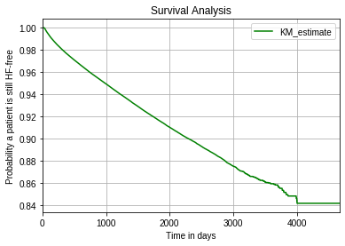

```python
##Data Preparation
sedata = pd.read_csv(Filename, sep = '\t')
#slicing the control with longest duration to HF
sdata = sedata.sort_values(['diab_to_event'], ascending=True).groupby(['patient_sk']).tail(1)
#change label to binary variable
sdata.loc[sdata["label"] == "case", "label"] = 1
sdata.loc[sdata["label"] == "ctrl", "label"] = 0

#remove patient who has TIME_TO_HF > 5000 (outliers)
sdata  = sdata[sdata['diab_to_event']<=5000]

## Model initiation
kmf = KaplanMeierFitter()
#KM table
T = sdata['diab_to_event']
C = sdata['label']
kmf.fit(T, event_observed=C)
table = kmf.event_table
table['survival prob'] = kmf.survival_function_

# show life table (function), if possible
print(table.sample(n=20).sort_values(by='event_at'))

##PLotting the survival function
kmf.survival_function_.plot(title='Survival Analysis', color = 'green')
plt.style.use('seaborn-ticks')
plt.ylabel("Probability a patient is still HF-free")
plt.xlabel('Time in days')
plt.grid(True)
plt.show()
```

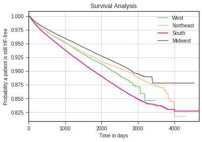

```python
### Survival for different subgroups
def sub_survival_analysis(data, covar, value_list=''):
    '''
    data: the data source
    covar (string): the column name from which subgroup will be extracted.
    value_list (list or ''): list of value in the column for subgroup extraction.
                            If not specified, analysis will be done on all subgroups.
    '''
    if value_list =='': value_list = data[covar].unique()
    ax = plt.subplot(111)
    plt.gca().set_prop_cycle(plt.cycler('color', plt.cm.Accent(np.linspace(0,1,len(value_list)))))
    for name in value_list:
        idx = data[covar]==name
        T = data[idx]['diab_to_event']
        C = data[idx]['label']
        kmf.fit(T,C,label=name)
        kmf.survival_function_.plot(title='Survival Analysis', ax=ax)
        plt.ylabel('Probability a patient is still HF-free')
        plt.xlabel('Time in days')
        plt.grid(True)
    plt.show()

sub_survival_analysis(sdata, 'census_region')
```

# Baseline Analysis

## Rationale

The goal of this analaysis is to explore the chararistics of the data. We use logistic regression and RNN for the prediction of case/control labels. For simplicity, we used our cases and randomly selected equal count from our control set. We explored the performance of the data collected before the onset of diabetes and those collected afterwards. As described in the cohort extraction we excluded cases who developed HF within 30 days of their first DM encounter. The analysis plan for the full project is described in the proposal.

#### Data Loading and Preparation

```python
### A random sample of around 80,000 patients that represent an equal ration of cases and controls were selected
### for a primary analysis which are further subdivided into training validation and testing sets
## processed Data Loading
##### PreDiab
train_sl_pre= pickle.load(open('../preprocessed_data/lr_dhf_tmp5_DM_40Kcsct_pre.combined.train', 'rb'), encoding='bytes')
test_sl_pre= pickle.load(open('../preprocessed_data/lr_dhf_tmp5_DM_40Kcsct_pre.combined.test', 'rb'), encoding='bytes')
valid_sl_pre= pickle.load(open('../preprocessed_data/lr_dhf_tmp5_DM_40Kcsct_pre.combined.valid', 'rb'), encoding='bytes')
#### Pre&PostDiab
train_sl_prepost= pickle.load(open('../preprocessed_data/lr_dhf_tmp5_40Kcsct_prepost.combined.train', 'rb'), encoding='bytes')
test_sl_prepost= pickle.load(open('../preprocessed_data/lr_dhf_tmp5_40Kcsct_prepost.combined.test', 'rb'), encoding='bytes')
valid_sl_prepost= pickle.load(open('../preprocessed_data/lr_dhf_tmp5_40Kcsct_prepost.combined.valid', 'rb'), encoding='bytes')
### Our current data include around 69K feature mainly ICD 9 and 10 codes for diagosis and Medication generic name
### We plan to add other variables like procdeures , surgery , other clincial events including vital signs measurements  and lab tests and results
# types dictionary
types_d=pickle.load(open('../preprocessed_data/lr_dhf_tmp5_DM_40Kcsct.types.Final', 'rb'), encoding='bytes')
input_size_1=[max(types_d.values())+1]
types_d_rev = dict(zip(types_d.values(),types_d.keys()))
print (input_size_1)
print (len(train_sl_pre),len(valid_sl_pre),len(test_sl_pre))
print (len(train_sl_prepost),len(valid_sl_prepost),len(test_sl_prepost)) ### numbers should match they are the same subset of patients

#### PrePostDiab using UMLS
train_sl_ppumls= pickle.load(open('../preprocessed_data/lr_dhf_tmp5_DumlsM_40Kcsct.combined.train', 'rb'), encoding='bytes')
test_sl_ppumls= pickle.load(open('../preprocessed_data/lr_dhf_tmp5_DumlsM_40Kcsct.combined.test', 'rb'), encoding='bytes')
valid_sl_ppumls= pickle.load(open('../preprocessed_data/lr_dhf_tmp5_DumlsM_40Kcsct.combined.valid', 'rb'), encoding='bytes')

# UMLS types dictionary
umlstypes_d=pickle.load(open('../preprocessed_data/lr_dhf_tmp5_DumlsM_40Kcsct.types.train', 'rb'), encoding='bytes')
umlsinput_size_1=[max(umlstypes_d.values())+1]
umlstypes_d_rev = dict(zip(umlstypes_d.values(),umlstypes_d.keys()))
print (umlsinput_size_1)
print (len(train_sl_ppumls),len(valid_sl_ppumls),len(test_sl_ppumls))
```

```
[69056]
55833 7975 15951
55833 7975 15951
[50523]
55833 7975 15951
```

```python
##### Data conversion to onehot matrices for Logestic Regression and may be Random Forest Basic test
pts_tr_pre=[]
labels_tr_pre=[]
features_tr_pre=[]
for pt in train_sl_pre:
    pts_tr_pre.append(pt[0])
    labels_tr_pre.append(pt[1])
    x=[]
    for v in pt[-1]:
        x.extend(v[-1])
    features_tr_pre.append(x)

pts_t_pre=[]
labels_t_pre=[]
features_t_pre=[]
for pt in test_sl_pre:
    pts_t_pre.append(pt[0])
    labels_t_pre.append(pt[1])
    x=[]
    for v in pt[-1]:
        x.extend(v[-1])
    features_t_pre.append(x)

pts_tr_prepost=[]
labels_tr_prepost=[]
features_tr_prepost=[]
for pt in train_sl_prepost:
    pts_tr_prepost.append(pt[0])
    labels_tr_prepost.append(pt[1])
    x=[]
    for v in pt[-1]:
        x.extend(v[-1])
    features_tr_prepost.append(x)

pts_t_prepost=[]
labels_t_prepost=[]
features_t_prepost=[]
for pt in test_sl_prepost:
    pts_t_prepost.append(pt[0])
    labels_t_prepost.append(pt[1])
    x=[]
    for v in pt[-1]:
        x.extend(v[-1])
    features_t_prepost.append(x)

pts_tr_ppumls=[]
labels_tr_ppumls=[]
features_tr_ppumls=[]
for pt in train_sl_ppumls:
    pts_tr_ppumls.append(pt[0])
    labels_tr_ppumls.append(pt[1])
    x=[]
    for v in pt[-1]:
        x.extend(v[-1])
    features_tr_ppumls.append(x)

pts_t_ppumls=[]
labels_t_ppumls=[]
features_t_ppumls=[]
for pt in test_sl_ppumls:
    pts_t_ppumls.append(pt[0])
    labels_t_ppumls.append(pt[1])
    x=[]
    for v in pt[-1]:
        x.extend(v[-1])
    features_t_ppumls.append(x)
mlb = MultiLabelBinarizer(classes=range(69056)[1:])
nfeatures_tr_pre = mlb.fit_transform(features_tr_pre)
nfeatures_t_pre = mlb.fit_transform(features_t_pre)
nfeatures_tr_prepost = mlb.fit_transform(features_tr_prepost)
nfeatures_t_prepost = mlb.fit_transform(features_t_prepost)

#umls
umlb = MultiLabelBinarizer(classes=range(50523)[1:])
nfeatures_tr_ppumls = umlb.fit_transform(features_tr_ppumls)
nfeatures_t_ppumls = umlb.fit_transform(features_t_ppumls)
```

```python
### Model Evaluation
def evaluate(model, test_features, test_labels):
    predictions = model.predict(test_features)
    pred_prob=model.predict_proba(test_features)
    auc_p=roc_auc_score(test_labels,pred_prob[:,1])
    print('Model Performance')
    print('AUC = {:0.2f}%.'.format(auc_p*100))
    return test_labels,pred_prob[:,1]
```

```python
### ROC curve plotting

def plot_roc_curve(label,score):
    fpr, tpr, ths = m.roc_curve(label, score) ### If I round it gives me an AUC of 64%
    roc_auc = m.auc(fpr, tpr)
    plt.figure()
    plt.plot(fpr, tpr, color='darkorange',lw=3, label='ROC curve (area = %0.2f)' % roc_auc)
    plt.plot([0, 1], [0, 1], color='navy', lw=1, linestyle='--')
    plt.xlim([0.0, 1.0])
    plt.ylim([0.0, 1.05])
    plt.ylabel('Sensitivity')
    plt.xlabel('1-Specificity')
    plt.title('ROC')
    plt.legend(loc="lower right")
    plt.show()
```

```python
#### Interactive Plot showing the deep learning model training AUC change over epochs

def plot_DLauc_perf(train_auc_allepv,test_auc_allepv,valid_auc_allepv,title_m):
    epochs=100
    train_auc_fg= go.Scatter(x= np.arange(epochs), y=train_auc_allepv, name='train')
    test_auc_fg= go.Scatter(x= np.arange(epochs), y=test_auc_allepv, name='test')
    valid_auc_fg= go.Scatter(x= np.arange(epochs), y=valid_auc_allepv, name='valid')
    valid_max = max(valid_auc_allepv)
    test_max = max(test_auc_allepv)
    data = [train_auc_fg,test_auc_fg,valid_auc_fg]
    layout = go.Layout(xaxis=dict(dtick=1),title=title_m)
    layout.update(dict(annotations=[go.layout.Annotation(text="Max Valid", x=valid_auc_allepv.index(valid_max), y=valid_max)]))
    fig = go.Figure(data=data, layout=layout)
    iplot(fig, filename=title_m)
```

```python
### for tracking computational timing
def timeSince(since):
    now = time.time()
    s = now - since
    m = math.floor(s / 60)
    s -= m * 60
    return '%dm %ds' % (m, s)
```

```python
### DL RNN Model training
import models as model
from EHRDataloader import EHRdataloader
from EHRDataloader import EHRdataFromLoadedPickles as EHRDataset
import utils as ut
from EHREmb import EHREmbeddings


def run_dl_model(ehr_model,train_sl,valid_sl,test_sl,bmodel_pth,bmodel_st):
    ## Data Loading
    print (' creating the list of training minibatches')
    train = EHRDataset(train_sl,sort= True, model='RNN')
    train_mbs = list(tqdm(EHRdataloader(train, batch_size = 128, packPadMode = True)))
    print (' creating the list of valid minibatches')
    valid = EHRDataset(valid_sl,sort= True, model='RNN')
    valid_mbs = list(tqdm(EHRdataloader(valid, batch_size = 128, packPadMode = True)))
    print (' creating the list of test minibatches')
    test = EHRDataset(test_sl,sort= True, model='RNN')
    test_mbs = list(tqdm(EHRdataloader(test, batch_size = 128, packPadMode = True)))


    ##Hyperparameters -- Fixed for testing purpose
    epochs = 100
    l2 = 0.0001
    lr = 0.01
    eps = 1e-4
    w_model='RNN'
    optimizer = optim.Adamax(ehr_model.parameters(), lr=lr, weight_decay=l2 ,eps=eps)

    ##Training epochs
    bestValidAuc = 0.0
    bestTestAuc = 0.0
    bestValidEpoch = 0
    train_auc_allep =[]
    valid_auc_allep =[]
    test_auc_allep=[]
    for ep in range(epochs):
        start = time.time()
        current_loss, train_loss = ut.trainbatches(train_mbs, model= ehr_model, optimizer = optimizer)
        avg_loss = np.mean(train_loss)
        train_time = timeSince(start)
        eval_start = time.time()
        Train_auc, y_real, y_hat  = ut.calculate_auc(ehr_model, train_mbs, which_model = w_model)
        valid_auc, y_real, y_hat  = ut.calculate_auc(ehr_model, valid_mbs, which_model = w_model)
        TestAuc, y_real, y_hat = ut.calculate_auc(ehr_model, test_mbs, which_model = w_model)
        eval_time = timeSince(eval_start)
        print ("Epoch: " ,str(ep) ," Train_auc :" , str(Train_auc) , " , Valid_auc : " ,str(valid_auc) , " ,& Test_auc : " , str(TestAuc) ," Avg Loss: " ,str(avg_loss), ' , Train Time :' , str(train_time) ,' ,Eval Time :' ,str(eval_time))
        train_auc_allep.append(Train_auc)
        valid_auc_allep.append(valid_auc)
        test_auc_allep.append(TestAuc)

        if valid_auc > bestValidAuc:
            bestValidAuc = valid_auc
            bestValidEpoch = ep
            bestTestAuc = TestAuc
            ###uncomment the below lines to save the best model parameters
            best_model = ehr_model
            torch.save(best_model, bmodel_pth)
            torch.save(best_model.state_dict(), bmodel_st)
        if ep - bestValidEpoch >5: break
    print( 'bestValidAuc %f has a TestAuc of %f at epoch %d ' % (bestValidAuc, bestTestAuc, bestValidEpoch))
    return train_auc_allep,valid_auc_allep,test_auc_allep
```

## PreDiabetes Data Analysis

### Logestic Regression

```
Model Performance
AUC = 72.65%.
```

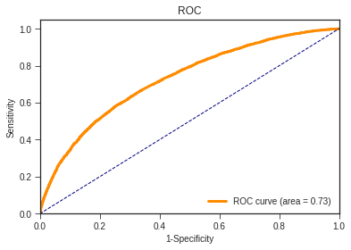

```
Highly contributing factors based on coefficients:
44905 1.513349018861055 D_11198
45439 1.784904246483 D_4172
45445 1.5404498361496846 D_136201
46425 1.8552746052086695 D_107577
47128 1.5654059027455411 D_130156
48640 2.0164644758046824 D_136192
49125 1.6413888888699428 D_124012
```

```python
EHR_LR= lm.LogisticRegression()
EHR_LR.fit(nfeatures_tr_pre, labels_tr_pre)
labels,scores=evaluate(EHR_LR,nfeatures_t_pre, labels_t_pre)

plot_roc_curve(labels,scores)

print ("Highly contributing factors based on coefficients: ")
f_imp=EHR_LR.coef_
## top contributing factors in both directions
for i,j in enumerate(f_imp[0].tolist()):
    if j>1.5:
        print (i+1,j,types_d_rev[i+1])
```

##### Variables appears above with highest positive coeffiecient

- D_4172 ICD9 041.19 "OTHER STAPHYLOCOCCUS INFECTION IN CONDITIONS CLASSIFIED ELSEWHERE AND OF UNSPECIFIED SITE"
- D_107577 ICD10-CM R19.5 "Other fecal abnormalities"
- D_136192 ICD10-CM I42.0 "Dilated cardiomyopathy"
- D_124012 ICD10-CM H54.7 "Unspecified visual loss"

### RNN

```python
### Import the RNN model definition that include the definition of the embedding architucture and different variations of RNN architictures
### we will use a very basic GRU layer for this primary analysis
#import models as model
#import utils as TVT

ehr_model_pre = model.EHR_RNN(input_size_1, embed_dim=128, hidden_size=128, n_layers=1, dropout_r=0., cell_type='GRU', bii=False , time=True)
if use_cuda: ehr_model_pre = ehr_model_pre.cuda()

### Model training
train_auc_allep_pre,valid_auc_allep_pre,test_auc_allep_pre=run_dl_model(ehr_model_pre,train_sl_pre,valid_sl_pre,test_sl_pre,'bestGRU.pth','bestGRU.st')
```

```
 creating the list of training minibatches
```

```
 creating the list of valid minibatches
```

```
 creating the list of test minibatches
```

```
Epoch:  0  Train_auc : 0.7439878525745418  , Valid_auc :  0.7234290975030262  ,& Test_auc :  0.7238737214779134  Avg Loss:  0.6289788666127741  , Train Time : 0m 2s  ,Eval Time : 0m 0s
Epoch:  1  Train_auc : 0.7675684886093923  , Valid_auc :  0.7353534802668343  ,& Test_auc :  0.7381487487540993  Avg Loss:  0.5985212502808408  , Train Time : 0m 2s  ,Eval Time : 0m 0s
Epoch:  2  Train_auc : 0.778074484239485  , Valid_auc :  0.7423752676784794  ,& Test_auc :  0.7417109950541281  Avg Loss:  0.585755160622213  , Train Time : 0m 2s  ,Eval Time : 0m 0s
Epoch:  3  Train_auc : 0.7891821210190271  , Valid_auc :  0.7444574734975975  ,& Test_auc :  0.7438695317928707  Avg Loss:  0.5794419842204828  , Train Time : 0m 2s  ,Eval Time : 0m 0s
Epoch:  4  Train_auc : 0.790154490441954  , Valid_auc :  0.7398658015912134  ,& Test_auc :  0.736197062975761  Avg Loss:  0.5713265738953119  , Train Time : 0m 2s  ,Eval Time : 0m 0s
Epoch:  5  Train_auc : 0.8017829499550739  , Valid_auc :  0.741868625377442  ,& Test_auc :  0.7383564014928798  Avg Loss:  0.5640651689863753  , Train Time : 0m 2s  ,Eval Time : 0m 0s
Epoch:  6  Train_auc : 0.8092221900510069  , Valid_auc :  0.7395744720465796  ,& Test_auc :  0.7372251079256578  Avg Loss:  0.5546391264460553  , Train Time : 0m 2s  ,Eval Time : 0m 0s
Epoch:  7  Train_auc : 0.8254905122988301  , Valid_auc :  0.7364087832508187  ,& Test_auc :  0.7374935071672699  Avg Loss:  0.5458651314521658  , Train Time : 0m 2s  ,Eval Time : 0m 0s
Epoch:  8  Train_auc : 0.8387900614931879  , Valid_auc :  0.7407616800408408  ,& Test_auc :  0.7321683152906997  Avg Loss:  0.5351284819430319  , Train Time : 0m 2s  ,Eval Time : 0m 0s
Epoch:  9  Train_auc : 0.852503785500107  , Valid_auc :  0.7329814859964306  ,& Test_auc :  0.7316771317086055  Avg Loss:  0.5218823068100831  , Train Time : 0m 2s  ,Eval Time : 0m 0s
bestValidAuc 0.744457 has a TestAuc of 0.743870 at epoch 3
```

```python
#### Interactive Plot showing the model training AUC change over epochs
plot_DLauc_perf(train_auc_allep_pre,test_auc_allep_pre,valid_auc_allep_pre,'PreDiab_GRU_Auc')
```

[interactive chart not shown]

## Pre and Post Diabetes Data Analysis

### Logestic Regression

```
Model Performance
AUC = 81.56%.
```

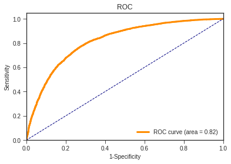

```
Highly contributing factors based on coefficients:
45393 1.5402812575637699 D_142069
45645 1.518677593037897 D_133909
46070 1.6316326406621346 D_134070
46083 1.545550819111415 D_172470
46196 1.523751789796195 D_137323
47768 1.594103846400101 D_135060
48797 1.7918351373038677 D_133335
49014 1.6245099633259543 D_189719
49980 1.6528527159358963 D_136205
55891 1.534646595867472 D_140264
```

```python
EHR_LR_pp= lm.LogisticRegression()
EHR_LR_pp.fit(nfeatures_tr_prepost, labels_tr_prepost)
labels_pps,scores_pps=evaluate(EHR_LR_pp,nfeatures_t_prepost, labels_t_prepost)

plot_roc_curve(labels_pps,scores_pps)

#### Will take that out
print ("Highly contributing factors based on coefficients: ")
f_imp=EHR_LR_pp.coef_
## top contributing factors in both directions
for i,j in enumerate(f_imp[0].tolist()):
    if j>1.5:
        print (i+1,j,types_d_rev[i+1])
```

##### Variables appears above with highest positive coeffiecient

- D_133335 ICD10-CM I21.09 "ST elevation (STEMI) myocardial infarction involving other coronary artery of anterior wall"
- D_136205 ICD10-CM I44.1 "Atrioventricular block, second degree"
- D_134070 ICD10-CM K94.23 "Gastrostomy malfunction"
- D_189719 ICD10-CM M12.811 "Other specific arthropathies, not elsewhere classified, right shoulder
- D_135060 ICD10-CM I27.81 "Cor pulmonale (chronic)
- D_172470 ICD10-CM T50.1X5A "Adverse effect of loop [high-ceiling] diuretics, initial encounter"
- D_142069 ICD10-CM E11.610 "Type 2 diabetes mellitus with diabetic neuropathic arthropathy
- D_140264 ICD10-CM C79.2 "Secondary malignant neoplasm of skin
- D_137323 ICD10-CM I51.3 "Intracardiac thrombosis, not elsewhere classified"
- D_133909 ICD10-CM I25.5 "Ischemic cardiomyopathy

```python
ehr_model_prepost = model.EHR_RNN(input_size_1, embed_dim=128, hidden_size=128, n_layers=1, dropout_r=0., cell_type='GRU', bii=False , time=True)
if use_cuda: ehr_model_prepost = ehr_model_prepost.cuda()

### Model training
train_auc_allep_prepost,valid_auc_allep_prepost,test_auc_allep_prepost=run_dl_model(ehr_model_prepost,train_sl_prepost,valid_sl_prepost,test_sl_prepost,'DHF_prepost_bmodel.pth','DHF_prepost_bmodel.st')
```

```
 creating the list of training minibatches
```

```
 creating the list of valid minibatches
```

```
 creating the list of test minibatches
```

```
Epoch:  0  Train_auc : 0.8633368139240603  , Valid_auc :  0.8491433785446091  ,& Test_auc :  0.8439865206905985  Avg Loss:  0.5241864213998291  , Train Time : 0m 3s  ,Eval Time : 0m 1s
Epoch:  1  Train_auc : 0.8852920896271125  , Valid_auc :  0.8610774481808935  ,& Test_auc :  0.85791220841207  Avg Loss:  0.46593213485575274  , Train Time : 0m 3s  ,Eval Time : 0m 1s
Epoch:  2  Train_auc : 0.8959374040568426  , Valid_auc :  0.8627730911766179  ,& Test_auc :  0.8608551909647437  Avg Loss:  0.4455658239194716  , Train Time : 0m 3s  ,Eval Time : 0m 0s
Epoch:  3  Train_auc : 0.9075729975127248  , Valid_auc :  0.8635472232517146  ,& Test_auc :  0.862141542181403  Avg Loss:  0.4301443575442521  , Train Time : 0m 2s  ,Eval Time : 0m 0s
Epoch:  4  Train_auc : 0.9199005859829182  , Valid_auc :  0.8626193907032694  ,& Test_auc :  0.8632460311970395  Avg Loss:  0.41540920802916614  , Train Time : 0m 2s  ,Eval Time : 0m 0s
Epoch:  5  Train_auc : 0.9266006369438683  , Valid_auc :  0.8613791565174662  ,& Test_auc :  0.8595591555229953  Avg Loss:  0.39314465152806244  , Train Time : 0m 3s  ,Eval Time : 0m 0s
Epoch:  6  Train_auc : 0.9424591517456544  , Valid_auc :  0.8541994227630433  ,& Test_auc :  0.8544301635313463  Avg Loss:  0.37154203543717834  , Train Time : 0m 3s  ,Eval Time : 0m 0s
Epoch:  7  Train_auc : 0.9551167307825414  , Valid_auc :  0.8497345922745053  ,& Test_auc :  0.8473351166351718  Avg Loss:  0.3449176819845178  , Train Time : 0m 3s  ,Eval Time : 0m 0s
Epoch:  8  Train_auc : 0.9643500044616816  , Valid_auc :  0.8460469445968763  ,& Test_auc :  0.8454248796546378  Avg Loss:  0.3153189262953298  , Train Time : 0m 3s  ,Eval Time : 0m 1s
Epoch:  9  Train_auc : 0.9750724455448357  , Valid_auc :  0.8446969153727144  ,& Test_auc :  0.8415861848869493  Avg Loss:  0.28382073716185563  , Train Time : 0m 3s  ,Eval Time : 0m 0s
bestValidAuc 0.863547 has a TestAuc of 0.862142 at epoch 3
```

```python
#### Interactive Plot showing the model training AUC change over epochs
plot_DLauc_perf(train_auc_allep_prepost,test_auc_allep_prepost,valid_auc_allep_prepost,'Pre&PostDiab_GRU_Auc')
```

[interactive chart not shown]

## Pre and PostDiabetes Data Analysis using UMLS Concept Unique Identifier (CUI )

### Logestic Regression

```
Model Performance
AUC = 81.81%.
```

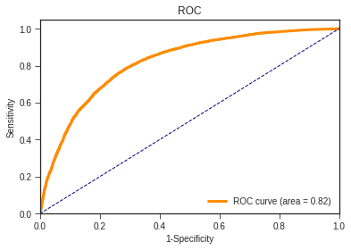

```
Highly contributing factors based on coefficients:
3806 1.6119266953762823 C2883570
11777 1.708256355362703 C2712647
13880 1.6367065241301366 C0260405
18189 1.5229015702504938 C4049006
18824 1.5483739975902768 C2889838
23426 1.5636031643547197 C1260422
```

```python
EHR_LR_upp= lm.LogisticRegression()
EHR_LR_upp.fit(nfeatures_tr_ppumls, labels_tr_ppumls)
labels_ups,scores_ups=evaluate(EHR_LR_upp,nfeatures_t_ppumls, labels_t_ppumls)

plot_roc_curve(labels_ups,scores_ups)

#### Will take that out
print ("Highly contributing factors based on coefficients: ")
f_imp=EHR_LR_upp.coef_
## top contributing factors in both directions
for i,j in enumerate(f_imp[0].tolist()):
    if j>1.5:
        print (i+1,j,umlstypes_d_rev[i+1])
```

##### Variables appears above with highest positive coeffiecient

- C2712647--Anemia due to antineoplastic chemotherapy
- C0260405--PERSONAL HISTORY OF MALIGNANT NEOPLASM OF GASTROINTESTINAL TRACT
- C2883570--Adverse effect of loop [high-ceiling] diuretics, initial encounter
- C1260422-- Nodular prostate with urinary obstruction
- C2889838-- Other mechanical complication of cardiac pulse generator (battery), initial encounter
- C4049006-- Selective deficiency of immunoglobulin A [IgA]

### RNN

```python
ehr_model_umls = model.EHR_RNN(umlsinput_size_1, embed_dim=128, hidden_size=128, n_layers=1, dropout_r=0., cell_type='GRU', bii=False , time=True)
if use_cuda: ehr_model_umls = ehr_model_umls.cuda()

### Model training
train_auc_allep_umls,valid_auc_allep_umls,test_auc_allep_umls=run_dl_model(ehr_model_umls,train_sl_ppumls,valid_sl_ppumls,test_sl_ppumls,'DHF_umls_bmodel.pth','DHF_umls_bmodel.st')
```

```
 creating the list of training minibatches
```

```
 creating the list of valid minibatches
```

```
 creating the list of test minibatches
```

```
Epoch:  0  Train_auc : 0.8631339549780523  , Valid_auc :  0.8475248845689631  ,& Test_auc :  0.8478074112619992  Avg Loss:  0.5215044936229445  , Train Time : 0m 3s  ,Eval Time : 0m 1s
Epoch:  1  Train_auc : 0.8792076487158555  , Valid_auc :  0.8574590868021771  ,& Test_auc :  0.8550605814308129  Avg Loss:  0.4714272813550358  , Train Time : 0m 3s  ,Eval Time : 0m 1s
Epoch:  2  Train_auc : 0.89202422632811  , Valid_auc :  0.8646171823479519  ,& Test_auc :  0.8622802183981411  Avg Loss:  0.45170134353911734  , Train Time : 0m 3s  ,Eval Time : 0m 1s
Epoch:  3  Train_auc : 0.9000230642121062  , Valid_auc :  0.8655093810440738  ,& Test_auc :  0.8643748801262723  Avg Loss:  0.4395730292660067  , Train Time : 0m 3s  ,Eval Time : 0m 1s
Epoch:  4  Train_auc : 0.9066631513012571  , Valid_auc :  0.8638730544168238  ,& Test_auc :  0.8642373201108027  Avg Loss:  0.4269208592244949  , Train Time : 0m 3s  ,Eval Time : 0m 1s
Epoch:  5  Train_auc : 0.9118802821107047  , Valid_auc :  0.8608534549803231  ,& Test_auc :  0.8606387972695515  Avg Loss:  0.4136177287362089  , Train Time : 0m 3s  ,Eval Time : 0m 1s
Epoch:  6  Train_auc : 0.9228424638347792  , Valid_auc :  0.864338558960722  ,& Test_auc :  0.8632802718500328  Avg Loss:  0.4035900347876823  , Train Time : 0m 3s  ,Eval Time : 0m 0s
Epoch:  7  Train_auc : 0.9328735072325822  , Valid_auc :  0.8636437774676301  ,& Test_auc :  0.8623619604896193  Avg Loss:  0.3851316794581797  , Train Time : 0m 3s  ,Eval Time : 0m 1s
Epoch:  8  Train_auc : 0.9388113285856181  , Valid_auc :  0.8602186503242837  ,& Test_auc :  0.8599694773977103  Avg Loss:  0.36731882338551275  , Train Time : 0m 3s  ,Eval Time : 0m 1s
Epoch:  9  Train_auc : 0.9491023069627205  , Valid_auc :  0.8503471297042032  ,& Test_auc :  0.8492531355822953  Avg Loss:  0.34825806830121175  , Train Time : 0m 3s  ,Eval Time : 0m 1s
bestValidAuc 0.865509 has a TestAuc of 0.864375 at epoch 3
```

```python
#### Interactive Plot showing the model training AUC change over epochs
plot_DLauc_perf(train_auc_allep_umls,test_auc_allep_umls,valid_auc_allep_umls,'PrePostDiab_UMLS_GRU_Auc')
```

[interactive chart not shown]

#### DeLong Test for AUC difference signifigance

We utilized the code available in https://github.com/yandexdataschool/roc_comparison with very slight modification

```python
Test_pt_sk_l_prepost=[]
Test_labels_prepost=[]
test_features_prepost=[]
lr_scores=[]
RNN_pred=[]
best_ehr_model_prepost=torch.load('DHF_prepost_bmodel.pth')
best_ehr_model_prepost.load_state_dict(torch.load('DHF_prepost_bmodel.st'))

for pt in test_sl_prepost:
    #print(pt)
    Test_pt_sk_l_prepost.append(pt[0])
    Test_labels_prepost.append(pt[1])
    tx=[]
    for v in pt[-1]:
        tx.extend(v[-1])
    test_features_prepost.append(tx)
    test_nfeatures_prepost = mlb.fit_transform([tx])
    pred_prob=EHR_LR_pp.predict_proba(test_nfeatures_prepost)
    lr_score=pred_prob[:,1]
    lr_scores.append(lr_score[0])
    #label,LR_score=evaluate(EHR_LR_pp,test_nfeatures_prepost, pt[1])
    #lr_scores.append(LR_score)
    test_dlg = EHRDataset([pt],sort= True, model='RNN')
    test_mbs_dlg = list(EHRdataloader(test_dlg, batch_size =1, packPadMode = True))
    #_, y_real, y_hat = ut.calculate_auc(best_ehr_model_prepost, test_mbs_dlg, which_model = 'RNN')
    for i,batch in enumerate(test_mbs_dlg):
        #batch.to(device)
        sample, label_tensor, seq_l, mtd = batch
        output = best_ehr_model_prepost(sample, seq_l, mtd)
        y_hat=output.cpu().data.view(-1).numpy()
        y_real=label_tensor.cpu().data.view(-1).numpy()
    RNN_pred.append(y_hat[0])
    #print(pt[0],pt[1],LR_score,y_hat)
    #print(pt[0],pt[1], y_real[0],lr_score[0], y_hat[0])
```

```python
import Delong_Calc as dlgc
print(np.asarray(Test_labels_prepost),np.asarray(lr_scores),np.asarray(RNN_pred))

pval=dlgc.delong_roc_test(np.asarray(Test_labels_prepost),np.asarray(lr_scores),np.asarray(RNN_pred))

print ('log p-value=', pval[0][0])
```

```
[0 1 0 ... 1 0 1] [6.34513068e-02 1.50808607e-09 6.73727748e-01 ... 5.96280031e-01
 6.10833003e-01 5.32237430e-01] [0.02507548 0.2991173  0.34247276 ... 0.62990284 0.65345794 0.7036109 ]
log p-value= -71.51986015290676
```